# Project: TMDb Movie Data Analysis

- Introduction
- Data Wrangling
- Exploratory Data Analysis
- Conclusions

## Introduction

> This report will include Data wrangling and analysis for TMDb Movie Dataset and answering questions regarding the movies genres and other variables and in particular:
> - Which genres of movies are most popular
> - What types of genres are most produced?
> - What movie genres are most profitable?
> - Do movies make more profit if they are released in certain month of the year?
> - How do the movies budget and revenue change over the years?
> - What is the Productions Rate over the years?
> - What is the Vote average for all movies?

```python
# importing the packeges needed for analysis

import pandas as pd
import numpy as np
import matplotlib.pyplot as plt
%matplotlib inline
```

## Data Wrangling

### Assessing the data

we only have one csv file to read using pd.read_csv()

```python
movies_data = pd.read_csv('tmdb-movies.csv')

movies_data.head()
```

|  | id | imdb_id | popularity | budget | revenue | original_title | cast | homepage | director | tagline | ... | overview | runtime | genres | production_companies | release_date | vote_count | vote_average | release_year | budget_adj | revenue_adj |
| --- | --- | --- | --- | --- | --- | --- | --- | --- | --- | --- | --- | --- | --- | --- | --- | --- | --- | --- | --- | --- | --- |
| 0 | 135397 | tt0369610 | 32.985763 | 150000000 | 1513528810 | Jurassic World | Chris Pratt\|Bryce Dallas Howard\|Irrfan Khan\|Vi... | http://www.jurassicworld.com/ | Colin Trevorrow | The park is open. | ... | Twenty-two years after the events of Jurassic ... | 124 | Action\|Adventure\|Science Fiction\|Thriller | Universal Studios\|Amblin Entertainment\|Legenda... | 6/9/15 | 5562 | 6.5 | 2015 | 1.379999e+08 | 1.392446e+09 |
| 1 | 76341 | tt1392190 | 28.419936 | 150000000 | 378436354 | Mad Max: Fury Road | Tom Hardy\|Charlize Theron\|Hugh Keays-Byrne\|Nic... | http://www.madmaxmovie.com/ | George Miller | What a Lovely Day. | ... | An apocalyptic story set in the furthest reach... | 120 | Action\|Adventure\|Science Fiction\|Thriller | Village Roadshow Pictures\|Kennedy Miller Produ... | 5/13/15 | 6185 | 7.1 | 2015 | 1.379999e+08 | 3.481613e+08 |
| 2 | 262500 | tt2908446 | 13.112507 | 110000000 | 295238201 | Insurgent | Shailene Woodley\|Theo James\|Kate Winslet\|Ansel... | http://www.thedivergentseries.movie/#insurgent | Robert Schwentke | One Choice Can Destroy You | ... | Beatrice Prior must confront her inner demons ... | 119 | Adventure\|Science Fiction\|Thriller | Summit Entertainment\|Mandeville Films\|Red Wago... | 3/18/15 | 2480 | 6.3 | 2015 | 1.012000e+08 | 2.716190e+08 |
| 3 | 140607 | tt2488496 | 11.173104 | 200000000 | 2068178225 | Star Wars: The Force Awakens | Harrison Ford\|Mark Hamill\|Carrie Fisher\|Adam D... | http://www.starwars.com/films/star-wars-episod... | J.J. Abrams | Every generation has a story. | ... | Thirty years after defeating the Galactic Empi... | 136 | Action\|Adventure\|Science Fiction\|Fantasy | Lucasfilm\|Truenorth Productions\|Bad Robot | 12/15/15 | 5292 | 7.5 | 2015 | 1.839999e+08 | 1.902723e+09 |
| 4 | 168259 | tt2820852 | 9.335014 | 190000000 | 1506249360 | Furious 7 | Vin Diesel\|Paul Walker\|Jason Statham\|Michelle ... | http://www.furious7.com/ | James Wan | Vengeance Hits Home | ... | Deckard Shaw seeks revenge against Dominic Tor... | 137 | Action\|Crime\|Thriller | Universal Pictures\|Original Film\|Media Rights ... | 4/1/15 | 2947 | 7.3 | 2015 | 1.747999e+08 | 1.385749e+09 |

5 rows × 21 columns

```python
movies_data.tail()
```

|  | id | imdb_id | popularity | budget | revenue | original_title | cast | homepage | director | tagline | ... | overview | runtime | genres | production_companies | release_date | vote_count | vote_average | release_year | budget_adj | revenue_adj |
| --- | --- | --- | --- | --- | --- | --- | --- | --- | --- | --- | --- | --- | --- | --- | --- | --- | --- | --- | --- | --- | --- |
| 10861 | 21 | tt0060371 | 0.080598 | 0 | 0 | The Endless Summer | Michael Hynson\|Robert August\|Lord 'Tally Ho' B... | NaN | Bruce Brown | NaN | ... | The Endless Summer, by Bruce Brown, is one of ... | 95 | Documentary | Bruce Brown Films | 6/15/66 | 11 | 7.4 | 1966 | 0.000000 | 0.0 |
| 10862 | 20379 | tt0060472 | 0.065543 | 0 | 0 | Grand Prix | James Garner\|Eva Marie Saint\|Yves Montand\|Tosh... | NaN | John Frankenheimer | Cinerama sweeps YOU into a drama of speed and ... | ... | Grand Prix driver Pete Aron is fired by his te... | 176 | Action\|Adventure\|Drama | Cherokee Productions\|Joel Productions\|Douglas ... | 12/21/66 | 20 | 5.7 | 1966 | 0.000000 | 0.0 |
| 10863 | 39768 | tt0060161 | 0.065141 | 0 | 0 | Beregis Avtomobilya | Innokentiy Smoktunovskiy\|Oleg Efremov\|Georgi Z... | NaN | Eldar Ryazanov | NaN | ... | An insurance agent who moonlights as a carthie... | 94 | Mystery\|Comedy | Mosfilm | 1/1/66 | 11 | 6.5 | 1966 | 0.000000 | 0.0 |
| 10864 | 21449 | tt0061177 | 0.064317 | 0 | 0 | What's Up, Tiger Lily? | Tatsuya Mihashi\|Akiko Wakabayashi\|Mie Hama\|Joh... | NaN | Woody Allen | WOODY ALLEN STRIKES BACK! | ... | In comic Woody Allen's film debut, he took the... | 80 | Action\|Comedy | Benedict Pictures Corp. | 11/2/66 | 22 | 5.4 | 1966 | 0.000000 | 0.0 |
| 10865 | 22293 | tt0060666 | 0.035919 | 19000 | 0 | Manos: The Hands of Fate | Harold P. Warren\|Tom Neyman\|John Reynolds\|Dian... | NaN | Harold P. Warren | It's Shocking! It's Beyond Your Imagination! | ... | A family gets lost on the road and stumbles up... | 74 | Horror | Norm-Iris | 11/15/66 | 15 | 1.5 | 1966 | 127642.279154 | 0.0 |

5 rows × 21 columns

The genres column values are separated by pipe , we need to change that

```python
movies_data.info()
```

```
<class 'pandas.core.frame.DataFrame'>
RangeIndex: 10866 entries, 0 to 10865
Data columns (total 21 columns):
 #   Column                Non-Null Count  Dtype
---  ------                --------------  -----
 0   id                    10866 non-null  int64
 1   imdb_id               10856 non-null  object
 2   popularity            10866 non-null  float64
 3   budget                10866 non-null  int64
 4   revenue               10866 non-null  int64
 5   original_title        10866 non-null  object
 6   cast                  10790 non-null  object
 7   homepage              2936 non-null   object
 8   director              10822 non-null  object
 9   tagline               8042 non-null   object
 10  keywords              9373 non-null   object
 11  overview              10862 non-null  object
 12  runtime               10866 non-null  int64
 13  genres                10843 non-null  object
 14  production_companies  9836 non-null   object
 15  release_date          10866 non-null  object
 16  vote_count            10866 non-null  int64
 17  vote_average          10866 non-null  float64
 18  release_year          10866 non-null  int64
 19  budget_adj            10866 non-null  float64
 20  revenue_adj           10866 non-null  float64
dtypes: float64(4), int64(6), object(11)
memory usage: 1.7+ MB
```

Release date is of object type we need to change it to datetime , and some important columns have null values like genres

homepage column is full of null values and this is obviuos as old movies didn't have web pages.

```python
movies_data.describe()
```

|  | id | popularity | budget | revenue | runtime | vote_count | vote_average | release_year | budget_adj | revenue_adj |
| --- | --- | --- | --- | --- | --- | --- | --- | --- | --- | --- |
| count | 10866.000000 | 10866.000000 | 1.086600e+04 | 1.086600e+04 | 10866.000000 | 10866.000000 | 10866.000000 | 10866.000000 | 1.086600e+04 | 1.086600e+04 |
| mean | 66064.177434 | 0.646441 | 1.462570e+07 | 3.982332e+07 | 102.070863 | 217.389748 | 5.974922 | 2001.322658 | 1.755104e+07 | 5.136436e+07 |
| std | 92130.136561 | 1.000185 | 3.091321e+07 | 1.170035e+08 | 31.381405 | 575.619058 | 0.935142 | 12.812941 | 3.430616e+07 | 1.446325e+08 |
| min | 5.000000 | 0.000065 | 0.000000e+00 | 0.000000e+00 | 0.000000 | 10.000000 | 1.500000 | 1960.000000 | 0.000000e+00 | 0.000000e+00 |
| 25% | 10596.250000 | 0.207583 | 0.000000e+00 | 0.000000e+00 | 90.000000 | 17.000000 | 5.400000 | 1995.000000 | 0.000000e+00 | 0.000000e+00 |
| 50% | 20669.000000 | 0.383856 | 0.000000e+00 | 0.000000e+00 | 99.000000 | 38.000000 | 6.000000 | 2006.000000 | 0.000000e+00 | 0.000000e+00 |
| 75% | 75610.000000 | 0.713817 | 1.500000e+07 | 2.400000e+07 | 111.000000 | 145.750000 | 6.600000 | 2011.000000 | 2.085325e+07 | 3.369710e+07 |
| max | 417859.000000 | 32.985763 | 4.250000e+08 | 2.781506e+09 | 900.000000 | 9767.000000 | 9.200000 | 2015.000000 | 4.250000e+08 | 2.827124e+09 |

Let's check for duplicates

```python
movies_data.duplicated().value_counts()
```

```
False    10865
True         1
dtype: int64
```

```python
movies_data[movies_data.duplicated(keep=False)]
```

|  | id | imdb_id | popularity | budget | revenue | original_title | cast | homepage | director | tagline | ... | overview | runtime | genres | production_companies | release_date | vote_count | vote_average | release_year | budget_adj | revenue_adj |
| --- | --- | --- | --- | --- | --- | --- | --- | --- | --- | --- | --- | --- | --- | --- | --- | --- | --- | --- | --- | --- | --- |
| 2089 | 42194 | tt0411951 | 0.59643 | 30000000 | 967000 | TEKKEN | Jon Foo\|Kelly Overton\|Cary-Hiroyuki Tagawa\|Ian... | NaN | Dwight H. Little | Survival is no game | ... | In the year of 2039, after World Wars destroy ... | 92 | Crime\|Drama\|Action\|Thriller\|Science Fiction | Namco\|Light Song Films | 3/20/10 | 110 | 5.0 | 2010 | 30000000.0 | 967000.0 |
| 2090 | 42194 | tt0411951 | 0.59643 | 30000000 | 967000 | TEKKEN | Jon Foo\|Kelly Overton\|Cary-Hiroyuki Tagawa\|Ian... | NaN | Dwight H. Little | Survival is no game | ... | In the year of 2039, after World Wars destroy ... | 92 | Crime\|Drama\|Action\|Thriller\|Science Fiction | Namco\|Light Song Films | 3/20/10 | 110 | 5.0 | 2010 | 30000000.0 | 967000.0 |

2 rows × 21 columns

only one duplicated element to be droped

### Assessment Summary

quality issues:

- One duplicate row to be deleted
- release date data type is object
- drop unnecessary columns like (homepage , overview , tagline)
- remove rows with genre null values
- change genres column data type to list of strings

tidiness issue:

- remove release_year column (can get year from release_date column)

### Data Cleaning

Make a copy of the original dataframe

```python
movies_clean = movies_data.copy()
```

#### Define

remove duplicate row using dataframe.drop_duplicates() function

#### Code

```python
movies_clean.drop_duplicates(inplace=True)
```

#### Test

```python
movies_clean.duplicated().value_counts()
```

```
False    10865
dtype: int64
```

#### Define

change release date data type to datetime using pd.to_datetime()

#### Code

```python
#change the release_date column to datetime
movies_clean['release_date'] = pd.to_datetime(movies_clean['release_date'],format='%m/%d/%y')
```

#### Test

```python
movies_clean['release_date'].head()
```

```
0   2015-06-09
1   2015-05-13
2   2015-03-18
3   2015-12-15
4   2015-04-01
Name: release_date, dtype: datetime64[ns]
```

While making analysis i found that some movies have release dates on the future , so i should correct the rows containing these errors ,so let's check first if the year in release_date is the same as release_year

```python
movies_clean['release_year'].equals(movies_clean.release_date.dt.year)
```

```
False
```

```python
#check for the rows where the dates are wrong
movies_clean.loc[movies_clean['release_year']!= movies_clean.release_date.dt.year]
```

|  | id | imdb_id | popularity | budget | revenue | original_title | cast | homepage | director | tagline | ... | overview | runtime | genres | production_companies | release_date | vote_count | vote_average | release_year | budget_adj | revenue_adj |
| --- | --- | --- | --- | --- | --- | --- | --- | --- | --- | --- | --- | --- | --- | --- | --- | --- | --- | --- | --- | --- | --- |
| 9719 | 62 | tt0062622 | 3.309196 | 12000000 | 56715371 | 2001: A Space Odyssey | Keir Dullea\|Douglas Rain\|Gary Lockwood\|William... | NaN | Stanley Kubrick | An epic drama of adventure and exploration | ... | Humanity finds a mysterious object buried bene... | 149 | Science Fiction\|Mystery\|Adventure | Stanley Kubrick Productions\|Metro-Goldwyn-Maye... | 2068-04-05 | 1708 | 7.7 | 1968 | 7.522756e+07 | 3.555466e+08 |
| 9720 | 871 | tt0063442 | 1.152937 | 5800000 | 33395426 | Planet of the Apes | Charlton Heston\|Roddy McDowall\|Kim Hunter\|Maur... | NaN | Franklin J. Schaffner | Somewhere in the Universe, there must be somet... | ... | Taylor and two other astronauts come out of de... | 112 | Adventure\|Science Fiction\|Mystery | Twentieth Century Fox Film Corporation\|APJAC P... | 2068-02-07 | 469 | 7.2 | 1968 | 3.635999e+07 | 2.093547e+08 |
| 9721 | 10331 | tt0063350 | 1.058272 | 114000 | 0 | Night of the Living Dead | Duane Jones\|Judith O'Dea\|Karl Hardman\|Marilyn ... | NaN | George A. Romero | If it doesn't scare you, you're already dead! | ... | A group of people try to survive an attack of ... | 96 | Horror | Laurel Group\|Off Color Films\|Image Ten\|Market ... | 2068-10-01 | 279 | 7.2 | 1968 | 7.146619e+05 | 0.000000e+00 |
| 9722 | 26690 | tt0062755 | 0.891163 | 0 | 0 | The Boston Strangler | Tony Curtis\|Henry Fonda\|George Kennedy\|Mike Ke... | NaN | Richard Fleischer | NaN | ... | Boston is being terrorized by a series of seem... | 116 | Crime\|Drama\|Mystery\|Thriller | Twentieth Century Fox Film Corporation | 2068-10-08 | 15 | 6.6 | 1968 | 0.000000e+00 | 0.000000e+00 |
| 9723 | 8069 | tt0062711 | 0.867192 | 0 | 0 | Barbarella | Jane Fonda\|John Phillip Law\|Anita Pallenberg\|M... | NaN | Roger Vadim | See Barbarella do her thing! | ... | In the far future, a highly sexual woman is ta... | 98 | Science Fiction | Dino de Laurentiis Cinematografica\|Marianne Pr... | 2068-10-10 | 63 | 5.4 | 1968 | 0.000000e+00 | 0.000000e+00 |
| ... | ... | ... | ... | ... | ... | ... | ... | ... | ... | ... | ... | ... | ... | ... | ... | ... | ... | ... | ... | ... | ... |
| 10861 | 21 | tt0060371 | 0.080598 | 0 | 0 | The Endless Summer | Michael Hynson\|Robert August\|Lord 'Tally Ho' B... | NaN | Bruce Brown | NaN | ... | The Endless Summer, by Bruce Brown, is one of ... | 95 | Documentary | Bruce Brown Films | 2066-06-15 | 11 | 7.4 | 1966 | 0.000000e+00 | 0.000000e+00 |
| 10862 | 20379 | tt0060472 | 0.065543 | 0 | 0 | Grand Prix | James Garner\|Eva Marie Saint\|Yves Montand\|Tosh... | NaN | John Frankenheimer | Cinerama sweeps YOU into a drama of speed and ... | ... | Grand Prix driver Pete Aron is fired by his te... | 176 | Action\|Adventure\|Drama | Cherokee Productions\|Joel Productions\|Douglas ... | 2066-12-21 | 20 | 5.7 | 1966 | 0.000000e+00 | 0.000000e+00 |
| 10863 | 39768 | tt0060161 | 0.065141 | 0 | 0 | Beregis Avtomobilya | Innokentiy Smoktunovskiy\|Oleg Efremov\|Georgi Z... | NaN | Eldar Ryazanov | NaN | ... | An insurance agent who moonlights as a carthie... | 94 | Mystery\|Comedy | Mosfilm | 2066-01-01 | 11 | 6.5 | 1966 | 0.000000e+00 | 0.000000e+00 |
| 10864 | 21449 | tt0061177 | 0.064317 | 0 | 0 | What's Up, Tiger Lily? | Tatsuya Mihashi\|Akiko Wakabayashi\|Mie Hama\|Joh... | NaN | Woody Allen | WOODY ALLEN STRIKES BACK! | ... | In comic Woody Allen's film debut, he took the... | 80 | Action\|Comedy | Benedict Pictures Corp. | 2066-11-02 | 22 | 5.4 | 1966 | 0.000000e+00 | 0.000000e+00 |
| 10865 | 22293 | tt0060666 | 0.035919 | 19000 | 0 | Manos: The Hands of Fate | Harold P. Warren\|Tom Neyman\|John Reynolds\|Dian... | NaN | Harold P. Warren | It's Shocking! It's Beyond Your Imagination! | ... | A family gets lost on the road and stumbles up... | 74 | Horror | Norm-Iris | 2066-11-15 | 15 | 1.5 | 1966 | 1.276423e+05 | 0.000000e+00 |

331 rows × 21 columns

Apparently they added 100 years by mistake to these dates

```python
#the count of the wrong years
wrong_years = movies_clean[movies_clean['release_date'] > '2016-01-01'].release_date.dt.year.value_counts()
wrong_years
```

```
2066    46
2064    42
2067    40
2068    39
2065    35
2063    34
2062    32
2060    32
2061    31
Name: release_date, dtype: int64
```

#### Define

subtract 100 years from the wrong years like in this [link](https://stackoverflow.com/questions/50674011/replace-the-year-in-pandas-datetime-column)

#### Code

```python
#100 years contains 36524 days (calculated using this link https://planetcalc.com/273/)
for yr in wrong_years.index:
    movies_clean['release_date'] = movies_clean['release_date'].mask(movies_clean['release_date'].dt.year == yr,
                            movies_clean['release_date'] - pd.to_timedelta(36525, unit='D'))
```

#### Test

```python
#Testing if the wrong dates are removed correctly
movies_clean[movies_clean['release_date'] > '2016-01-01'].release_date.dt.year.value_counts()
```

```
Series([], Name: release_date, dtype: int64)
```

Now there is no need for the release_year column

#### Define

drop release year column using dataframe.drop(column)

#### Code

```python
movies_clean.drop(columns=['release_year'],inplace= True)
```

#### Test

```python
# Test if the column is removed appropriatly
movies_clean.info()
```

```
<class 'pandas.core.frame.DataFrame'>
Int64Index: 10865 entries, 0 to 10865
Data columns (total 20 columns):
 #   Column                Non-Null Count  Dtype
---  ------                --------------  -----
 0   id                    10865 non-null  int64
 1   imdb_id               10855 non-null  object
 2   popularity            10865 non-null  float64
 3   budget                10865 non-null  int64
 4   revenue               10865 non-null  int64
 5   original_title        10865 non-null  object
 6   cast                  10789 non-null  object
 7   homepage              2936 non-null   object
 8   director              10821 non-null  object
 9   tagline               8041 non-null   object
 10  keywords              9372 non-null   object
 11  overview              10861 non-null  object
 12  runtime               10865 non-null  int64
 13  genres                10842 non-null  object
 14  production_companies  9835 non-null   object
 15  release_date          10865 non-null  datetime64[ns]
 16  vote_count            10865 non-null  int64
 17  vote_average          10865 non-null  float64
 18  budget_adj            10865 non-null  float64
 19  revenue_adj           10865 non-null  float64
dtypes: datetime64[ns](1), float64(4), int64(5), object(10)
memory usage: 1.7+ MB
```

#### Define

drop unnecessary columns using dataframe.drop() function

#### Code

```python
movies_clean = movies_clean.drop(columns = ['homepage','tagline','overview','keywords','production_companies'])
```

#### Test

```python
movies_clean.info()
```

```
<class 'pandas.core.frame.DataFrame'>
Int64Index: 10865 entries, 0 to 10865
Data columns (total 15 columns):
 #   Column          Non-Null Count  Dtype
---  ------          --------------  -----
 0   id              10865 non-null  int64
 1   imdb_id         10855 non-null  object
 2   popularity      10865 non-null  float64
 3   budget          10865 non-null  int64
 4   revenue         10865 non-null  int64
 5   original_title  10865 non-null  object
 6   cast            10789 non-null  object
 7   director        10821 non-null  object
 8   runtime         10865 non-null  int64
 9   genres          10842 non-null  object
 10  release_date    10865 non-null  datetime64[ns]
 11  vote_count      10865 non-null  int64
 12  vote_average    10865 non-null  float64
 13  budget_adj      10865 non-null  float64
 14  revenue_adj     10865 non-null  float64
dtypes: datetime64[ns](1), float64(4), int64(5), object(5)
memory usage: 1.3+ MB
```

#### Define

Drop rows with genre null values using data.dropna(axis=0)

#### Code

```python
#drop rows with null values in genre column
movies_clean.dropna(subset = ['genres'],inplace=True)
```

#### Test

```python
movies_clean.info()
```

```
<class 'pandas.core.frame.DataFrame'>
Int64Index: 10842 entries, 0 to 10865
Data columns (total 15 columns):
 #   Column          Non-Null Count  Dtype
---  ------          --------------  -----
 0   id              10842 non-null  int64
 1   imdb_id         10834 non-null  object
 2   popularity      10842 non-null  float64
 3   budget          10842 non-null  int64
 4   revenue         10842 non-null  int64
 5   original_title  10842 non-null  object
 6   cast            10767 non-null  object
 7   director        10800 non-null  object
 8   runtime         10842 non-null  int64
 9   genres          10842 non-null  object
 10  release_date    10842 non-null  datetime64[ns]
 11  vote_count      10842 non-null  int64
 12  vote_average    10842 non-null  float64
 13  budget_adj      10842 non-null  float64
 14  revenue_adj     10842 non-null  float64
dtypes: datetime64[ns](1), float64(4), int64(5), object(5)
memory usage: 1.3+ MB
```

#### Define

change genres data type to list of strings for easier analysis using str.split() function

#### Code

```python
#change genre object type to list
movies_clean['genres'] = movies_clean.genres.apply(lambda x : x.split('|'))
```

#### Test

```python
#checking the genre column
movies_clean['genres'].head()
```

```
0    [Action, Adventure, Science Fiction, Thriller]
1    [Action, Adventure, Science Fiction, Thriller]
2            [Adventure, Science Fiction, Thriller]
3     [Action, Adventure, Science Fiction, Fantasy]
4                         [Action, Crime, Thriller]
Name: genres, dtype: object
```

## Exploratory Data Analysis

### Research Question 1 (What is the most frequent movie genres?)

```python
#frequency of each unique genre item
movies_clean.genres.value_counts()
```

```
[Comedy]                                712
[Drama]                                 712
[Documentary]                           312
[Drama, Romance]                        289
[Comedy, Drama]                         280
                                       ...
[Drama, Western, War, Romance]            1
[Drama, Action, Crime, Foreign]           1
[Music, Animation, Comedy, Family]        1
[Crime, Drama, Family, Romance]           1
[Adventure, Action, Comedy, Western]      1
Name: genres, Length: 2039, dtype: int64
```

It looks we have more than 2000 unique genre classifications and this is because some movies have multible genres , so let's explode the genres column to see the frequency of each genre using the pandas [explode](https://stackoverflow.com/questions/51813266/get-unique-values-from-pandas-series-of-lists) method

```python
genres = movies_clean.explode('genres').genres
genres.value_counts()
```

```
Drama              4760
Comedy             3793
Thriller           2907
Action             2384
Romance            1712
Horror             1637
Adventure          1471
Crime              1354
Family             1231
Science Fiction    1229
Fantasy             916
Mystery             810
Animation           699
Documentary         520
Music               408
History             334
War                 270
Foreign             188
TV Movie            167
Western             165
Name: genres, dtype: int64
```

now it's time to make a bar chart to display the frequency of genres

```python
#unique values of movie genres
genres.value_counts().index
```

```
Index(['Drama', 'Comedy', 'Thriller', 'Action', 'Romance', 'Horror',
       'Adventure', 'Crime', 'Family', 'Science Fiction', 'Fantasy', 'Mystery',
       'Animation', 'Documentary', 'Music', 'History', 'War', 'Foreign',
       'TV Movie', 'Western'],
      dtype='object')
```

```python
len(genres.value_counts().index)
```

```
20
```

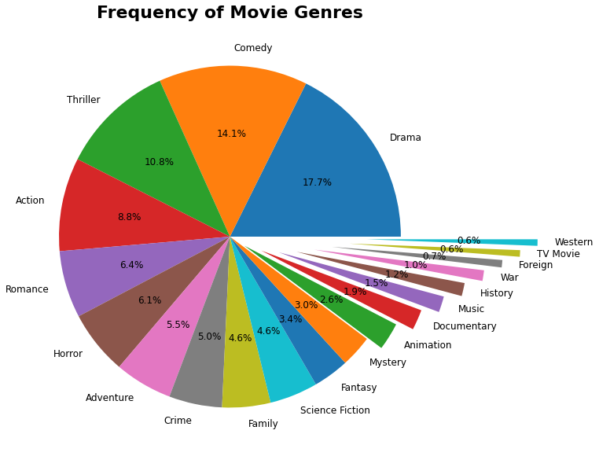

```python
sizes = genres.value_counts().values
labels= genres.value_counts().index
explode = (0,0,0,0,0,0,0,0,0,0,
           0,0,0.1,0.2,0.3,0.4,0.5,0.6,0.7,0.8)
fig , ax = plt.subplots(figsize=(20,10))
ax.pie(sizes,labels=labels,autopct='%1.1f%%',explode=explode,textprops={'fontsize': 12})
ax.set_title('Frequency of Movie Genres' , fontsize = 22 , weight = 'bold')
plt.show()
```

Drama and comdey are the most frequent movie genres , while Foreign ,tv movie , western are very little

### Research Question 2 (What are the most popular movie genres ?)

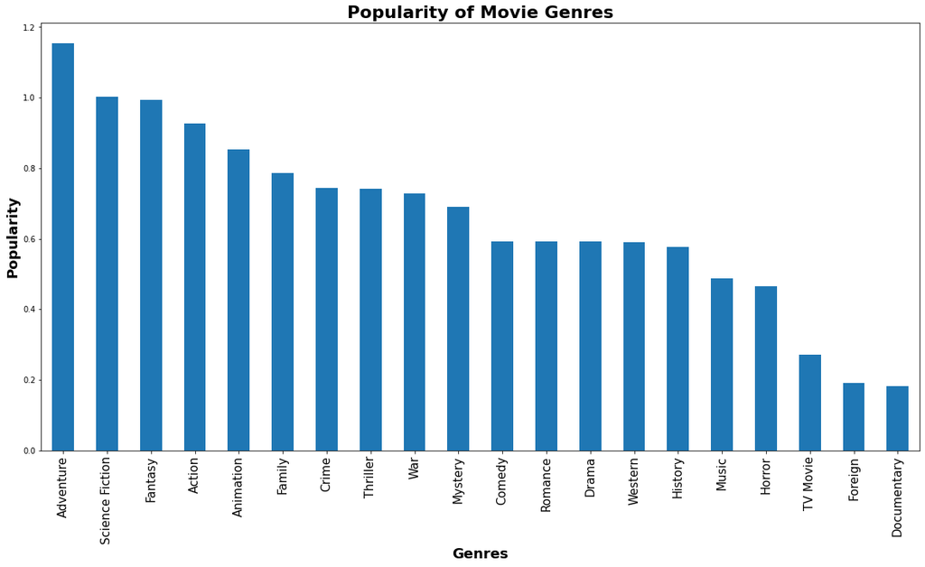

```python
fig = plt.subplots(figsize=(20,10))
genres_df = movies_clean.explode('genres')
genres_df.groupby('genres')['popularity'].mean().sort_values(ascending=False).plot(kind = 'bar')
plt.title('Popularity of Movie Genres',fontsize=22,weight ='bold')
plt.ylabel('Popularity',fontsize = 18,weight ='bold')
plt.xlabel('Genres',fontsize = 18,weight ='bold')
plt.xticks(fontsize=15);
```

People really likes Adventure and Science Fiction while Documentry movies are not so popular

### Research Question 3 (What are the most profitable movie genres ?)

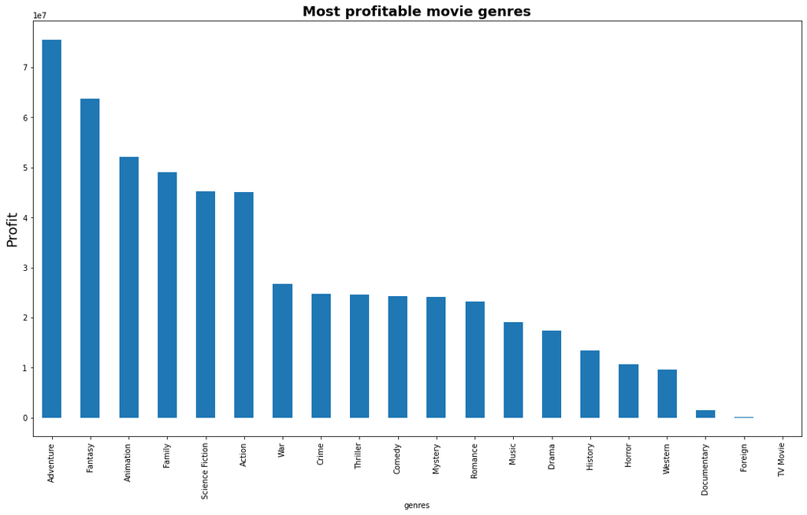

```python
genres_df['profit'] = genres_df['revenue'] - genres_df['budget']
plt.figure(figsize=(18,10))
genres_df.groupby('genres')['profit'].mean().sort_values(ascending = False).plot(kind = 'bar')
plt.title('Most profitable movie genres',fontsize = 18 , weight = 'bold')
plt.ylabel('Profit',fontsize = 18)
plt.show()
```

Adventure and Fantasy movies makes the most profits and that makes sense as they are very popular

### Research Question 4 (Do Movies make more profits in certain month?)

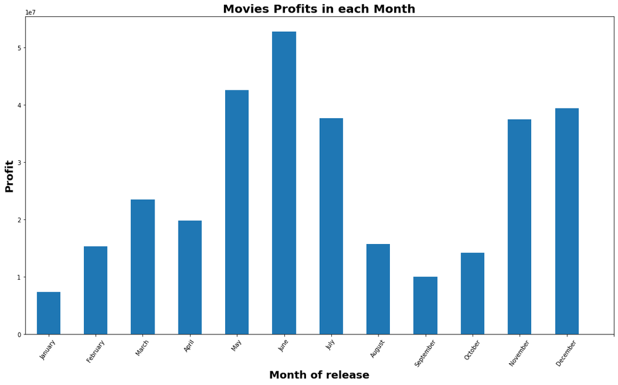

```python
ticks=['January' , 'February','March' , 'April','May','June','July','August','September','October','November','December']
ticks_loc= np.arange(13)
plt.figure(figsize=(18,10))
movies_clean['profit'] = movies_clean['revenue'] - movies_clean['budget']
movies_clean.groupby(movies_clean.release_date.dt.month)['profit'].mean().plot(kind='bar')
plt.title('Movies Profits in each Month',fontsize = 20,weight='bold')
plt.ylabel('Profit',fontsize = 18,weight= 'bold')
plt.xlabel('Month of release', fontsize= 18,weight = 'bold')
plt.xticks(ticks_loc,ticks,rotation=55)
plt.show()
```

Movies Make the most profits when they are released in May and June , and they make the lowest profit on January and september

### Research Question 5 ( How do the movies budget and revenue change over the years?)

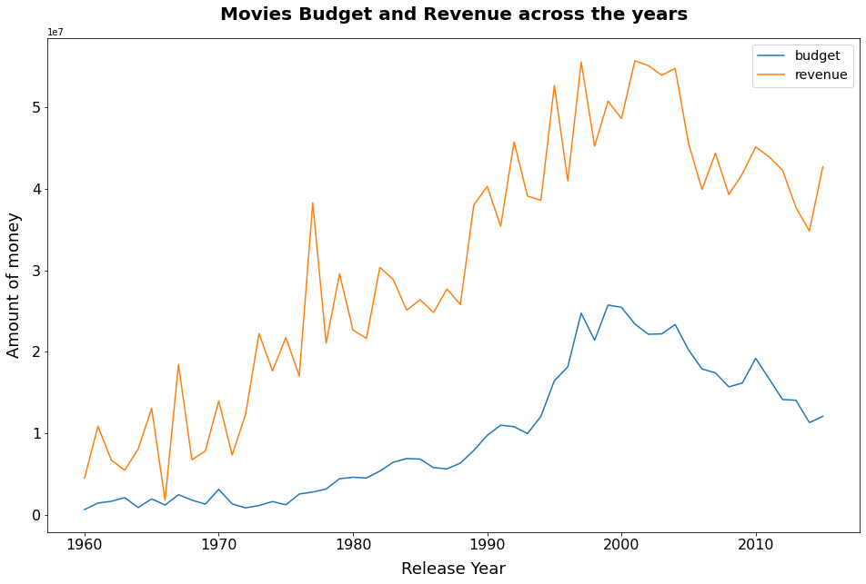

```python
plt.figure(figsize=(16,10))
movies_clean.groupby(movies_clean.release_date.dt.year)['budget'].mean().plot()
movies_clean.groupby(movies_clean.release_date.dt.year)['revenue'].mean().plot()
plt.legend(fontsize='x-large')
plt.ylabel('Amount of money',fontsize=18,labelpad=10)
plt.xlabel('Release Year',fontsize=18,labelpad=10)
plt.title('Movies Budget and Revenue across the years',fontsize=20,weight ='bold',pad=20)
plt.xticks(fontsize=16)
plt.yticks(fontsize=16)
plt.show();
```

As we see the the budget started to increase smoothly from 1975 to 2000 and then started to decrease again , while the revenue changes roughly but overall increases to after 2000 and then started to decrease

### Research Question 6 ( What is the Productions Rate over the years?)

```python
len(movies_clean.release_date.dt.year.unique())
```

```
56
```

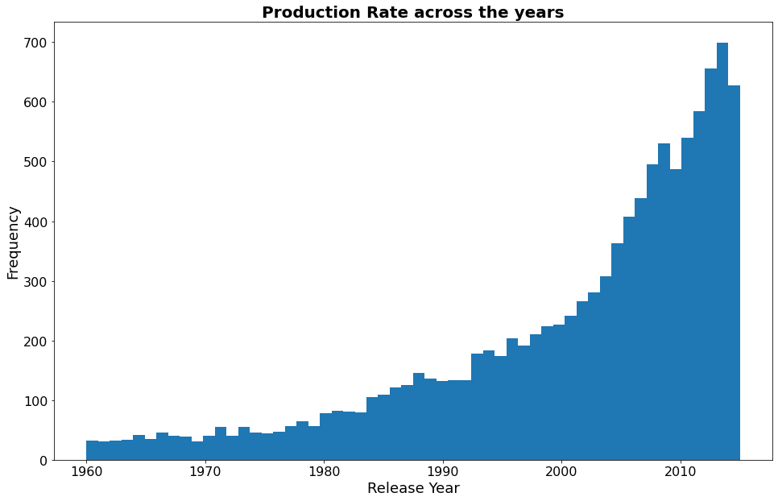

```python
plt.figure(figsize=(16,10))
release_year = movies_clean.release_date.dt.year
release_year.plot.hist(bins=56)
plt.xlabel('Release Year',fontsize=18)
plt.ylabel('Frequency',fontsize=18)
plt.title('Production Rate across the years',fontsize=20,weight='bold')
plt.xticks(fontsize=16)
plt.yticks(fontsize=16)
plt.show()
```

Production rate increase each year but decreased a little recently

### Research Question 7 ( What is the Vote average for all movies?)

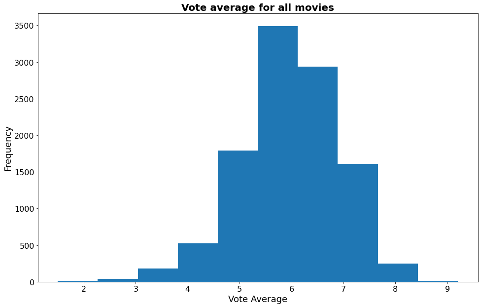

```python
plt.figure(figsize=(16,10))
vote_a = movies_clean.vote_average
vote_a.plot.hist(bins=10)
plt.xlabel('Vote Average',fontsize=18)
plt.ylabel('Frequency',fontsize=18)
plt.title('Vote average for all movies',fontsize=20,weight='bold')
plt.xticks(fontsize=16)
plt.yticks(fontsize=16)
plt.show();
```

Most movies takes votes between 5 and 7

## Conclusions

> People really like Adventure , Science Fiction , Action and Fantasy and that's why they are very profitable while Documentry movies are not so popular.

> Movies Make the most profits when they are released in May and June , and they make the lowest profit on January and september.

> Most Movies take votes from 5 to 7

### Limitations:

> When i had to correct the wrong dates on release_date column by decreasing it by 100 years or 36525 days i didn't consider the leap year for all values i took an average

```python
from subprocess import call
call(['python', '-m', 'nbconvert', 'Investigate_a_Dataset.ipynb'])
```

```
0
```